# ggparty: Graphic Partying

Martin Borkovec

2025-07-10

**ggparty** aims to extend **ggplot2** functionality to the **partykit** package. It provides the necessary tools to create clearly structured and highly customizable visualizations for tree-objects of the class `'party'`.

# ggparty

Loading the **ggparty** package will also load **partykit** and **ggplot2** and thereby provide all necessary functions.

```r
library(ggparty)
```

## Motivating Example

The following plot can be created fairly easily with **ggparty**. All it takes is an object of class `party`, some basic knowledge of **ggplot2** and comprehension of the topics covered in this vignette.

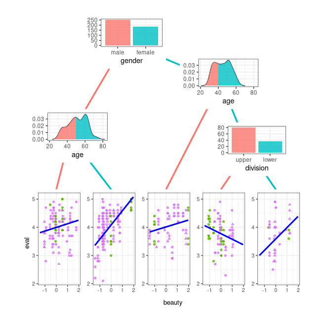

The code used to create this plot can be found at the end of this document. But first things first.  
Let’s recreate a simple example already used in the [partykit vignette](https://cran.r-project.org/package=partykit/vignettes/partykit.pdf). If you are not familiar with the [**partykit**](https://cran.r-project.org/package=partykit) you should definitely check it out before you work with this package.

```r
data("WeatherPlay", package = "partykit")
sp_o <- partysplit(1L, index = 1:3)
sp_h <- partysplit(3L, breaks = 75)
sp_w <- partysplit(4L, index = 1:2)
pn <- partynode(1L, split = sp_o, kids = list(
  partynode(2L, split = sp_h, kids = list(
    partynode(3L, info = "yes"),
    partynode(4L, info = "no"))),
  partynode(5L, info = "yes"),
  partynode(6L, split = sp_w, kids = list(
    partynode(7L, info = "yes"),
    partynode(8L, info = "no")))))
py <- party(pn, WeatherPlay)
```

## `ggparty()`

The `ggparty()` function takes a tree of class `party` and allows us to plot it with the help of the **ggplot2** package. To make this possible, the `'party'` object first needs to be transformed into a `'data.frame'` and be passed to a `ggplot()` call. This is exactly what happens when we run `ggparty()`.

```r
is.ggplot(ggparty(py))
```

[1] TRUE

```r
pander::pandoc.table(ggparty(py)$data[,1:16])
```

Table continues below

| id | x | y | parent | birth_order | breaks_label | info | info_list |
| --- | --- | --- | --- | --- | --- | --- | --- |
| 1 | 0.5 | 1 | NA | 0 | NA | NA | NA |
| 2 | 0.2 | 0.75 | 1 | 1 | sunny | NA | NA |
| 3 | 0.1 | 0.5 | 2 | 1 | NA <= NA* 75 | yes | NA |
| 4 | 0.3 | 0.5 | 2 | 2 | NA > NA* 75 | no | NA |
| 5 | 0.5 | 0.5 | 1 | 2 | overcast | yes | NA |
| 6 | 0.8 | 0.75 | 1 | 3 | rainy | NA | NA |
| 7 | 0.7 | 0.5 | 6 | 1 | false | yes | NA |
| 8 | 0.9 | 0.5 | 6 | 2 | true | no | NA |

| splitvar | level | kids | nodesize | p.value | horizontal | x_parent | y_parent |
| --- | --- | --- | --- | --- | --- | --- | --- |
| outlook | 0 | 3 | 14 | NA | FALSE | NA | NA |
| humidity | 1 | 2 | 5 | NA | FALSE | 0.5 | 1 |
| NA | 2 | 0 | 2 | NA | FALSE | 0.2 | 0.75 |
| NA | 2 | 0 | 3 | NA | FALSE | 0.2 | 0.75 |
| NA | 2 | 0 | 4 | NA | FALSE | 0.5 | 1 |
| windy | 1 | 2 | 5 | NA | FALSE | 0.5 | 1 |
| NA | 2 | 0 | 3 | NA | FALSE | 0.8 | 0.75 |
| NA | 2 | 0 | 2 | NA | FALSE | 0.8 | 0.75 |

## Plot Data

The first 16 columns of the `'data.frame'` passed by `ggparty()` to `ggplot()` contain these values:

- **id**… ID of the node
- **x**… X coordinate of the node
- **y**… Y coordinate of the node
- **parent**… ID of node’s parent
- **birth_order**… Position relative to parent. Goes from left to right.
- **breaks_label**… String containing the corresponding split break of the parent’s split variable.
- **info**… String containing the info of the node
- **info_list**… List containing the info of the node if it was a list
- **splitvar**… String containing the name of the Variable to split with. (only inner nodes)
- **level**… At which level to draw the node. (0 = root)
- **kids**… Number of node’s kids
- **nodesize**… Number of rows in node’s data.
- **p.value**… P value of model if present
- **horizontal**… Logical - specifies whether the tree is to be drawn horizontally or vertically. Identical for all nodes.
- **x_parent**… X coordinate of the node’s parent
- **y_parent**… Y coordinate of the node’s parent

The remaining columns contain lists of the node’s `data` and we will need `geom_node_plot()` to work with them.

# Plotting a Tree

Every **ggparty plot starts with a call to the eponymous `ggparty()` function which requires an object of class `'party'`. To draw a tree we will need to add several of these components:

## Basic Building Blocks

- **geom_edge()** draws the edges between the nodes
- **geom_edge_label()** labels the edges with the corresponding split breaks
- **geom_node_label()** labels the nodes with the split variable, node info or anything else. The shorthand versions of this geom **geom_node_splitvar()** and **geom_node_info()** have the correct defaults to write the split variables in the inner nodes or the info in the terminal nodes.
- **geom_node_plot()** creates a custom ggplot at the location of the node

In most cases we will probably want to draw at least edges, edge labels and node labels, so we will have to call the respective functions. The default mappings of `geom_edge()` and and `geom_edge_label()` ensure that lines between the related nodes are drawn and the corresponding split breaks are plotted at their centers.

Since the text we want to print on the nodes differs depending on the kind of node, we will call geom_node_label twice. Once for the inner nodes, to plot the split variables and once for the terminal nodes to plot the info elements of the tree, which in this case contain the play decision.

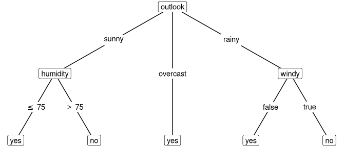

```r
ggparty(py) +
  geom_edge() +
  geom_edge_label() +
  geom_node_label(aes(label = splitvar), ids = "inner") +
  # identical to  geom_node_splitvar() +
  geom_node_label(aes(label = info), ids = "terminal")
```

```r
  # identical to geom_node_info()
```

Instead of adding `geom_node_label()` we can also add the convenience versions `geom_node_splitvar()` and `geom_node_info()` which contain the correct defaults to plot the split variables in the inner nodes and the info in the terminal nodes.  
Thanks to the ggplot2 mechanics we can now map different aspects of our plot to properties of the nodes. Whether that’s the best choice in this case is a different question.

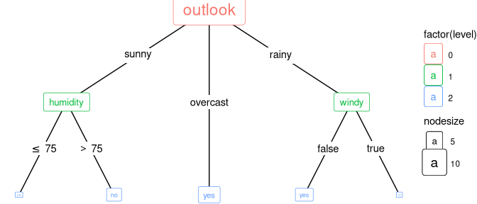

```r
ggparty(py) +
  geom_edge() +
  geom_edge_label() +
  # map color to level and size to nodesize for all nodes
  geom_node_splitvar(aes(col = factor(level),
                         size = nodesize)) +
  geom_node_info(aes(col = factor(level),
                     size = nodesize))
```

We can create a horizontal tree simply by setting `horizontal` in `ggparty()` to `TRUE`.

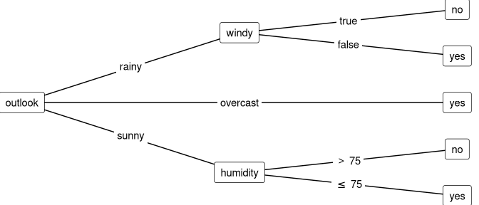

```r
ggparty(py, horizontal = TRUE) +
  geom_edge() +
  geom_edge_label() +
  geom_node_splitvar() +
  geom_node_info()
```

## Additional Data

This section is about extracting additional elements from the `'party'` object or adding new data. If you just want to know how to make pretty plots, feel free to skip forward to the next section.

If the default amount of elements extracted from the `'party'` object is not enough for our purposes, there is a way to add more. Setting the argument `add_vars` of the `ggparty()` call we can specify what to extract and how to store it (affecting how we can use it later on). Let’s say we want to add for each node the information whether the split break is closed on the right.  
We can do this the following way:

```r
gg <- ggparty(py, add_vars = list(right = "$node$split$right"))
gg$data$right
```

```
#> [1] TRUE TRUE   NA   NA   NA TRUE   NA   NA
```

As we can see we need to pass a named `'list'` to `add_vars`. The names of the elements of the list will become the names of the columns in the plot data and the elements of the list need to be either a `'character'` string specifying how to extract the desired element from each node (as seen above) or a function that will be applied consecutively to each node and each row of the plot data. If we want to simply add something to the plot data, so that it can be accessed by base level geoms (geoms making up the tree) it has to be of `length` one like in the example above. The same result can of course be achieved using a `'function:'`

```r
gg <- ggparty(py, add_vars = list(right =
                                    function(data, node) {
                                      node$node$split$right
                                      }
                                  )
              )
gg$data$right
```

```
#> [1] TRUE TRUE   NA   NA   NA TRUE   NA   NA
```

But what if we want to add data to our node’s `data` so that it is simultaneously accessible through a single geom?  
One way to do it, is to name the list element with the prefix `"nodedata_"` and assign a `'function'` which returns a `'list'` for each node. It is important that the lists be of the same `length` as the lists created from the node’s `data`. I.e. the new data has to have the same number of observations as the node’s data since it needs to fit into one `'data.frame'`. We are effectively adding columns to the node’s `data`.  
As we can see below, the plot data’s nodesize can be useful to make sure of this.  
Once we call `geom_node_plot()` this data will be readily available through `gglist` under its name (which we set for it as the name of the list element) without the prefix - just like all the node’s `data`.

```r
gg <- ggparty(py, add_vars = list(nodedata_x_dens =
                                    function(data, node) {
                                      list(density(node$data$temperature,
                                                   n = data$nodesize)$x)
                                    }
                                  )
              )
gg$data$nodedata_x_dens
```

```
#> [[1]]
#>  [1] 53.53320 56.75887 59.98453 63.21019 66.43585 69.66151 72.88717 76.11283
#>  [9] 79.33849 82.56415 85.78981 89.01547 92.24113 95.46680
#>
#> [[2]]
#> [1] 57.31698 67.15849 77.00000 86.84151 96.68302
#>
#> [[3]]
#> [1] 63.73772 80.26228
#>
#> [[4]]
#> [1] 61.48648 78.50000 95.51352
#>
#> [[5]]
#> [1]  46.43918  64.47973  82.52027 100.56082
#>
#> [[6]]
#> [1] 60.61887 65.30943 70.00000 74.69057 79.38113
#>
#> [[7]]
#> [1] 62.33887 71.50000 80.66113
#>
#> [[8]]
#> [1] 59.73772 76.26228
```

The obvious limitation of this method is that the number of observations has to be identical to the `nodesize`. In this case we achieved this by setting `n` of `density()` to the `nodesize`.

If we want to plot custom data of different dimensions we can simply supply it via the `data` argument of the `geoms` in `gglist`. Though in that case we won’t be able to access it simultaneously with the node’s `data` in the same `geom`. To ensure correct behaviour this `'data.frame'` has to contain a column named `id` specifying the `id` of the node it belongs to.

# Node Plots

If we want to plot the `data` contained within the individual nodes of the tree, we need to add `geom_node_plot()` to our `ggparty()` call. To understand why this is necessary let’s reiterate what `ggparty()` does and how it uses the `ggplot()` function. Every `ggplot()` call needs a `'data.frame'`, so as we’ve seen above `ggparty()` creates one from the `'party'` object. In this `'data.frame'` every row corresponds to a node of the tree.  
Each column of this node’s `data` is stored as a `'list'` in its own column. This way it is not usable by `ggplot()`, since `ggplot()` can’t handle lists inside its data. This is where `geom_node_plot()` comes into play and each instance of `geom_node_plot()` creates a completely separate `ggplot()` call after transforming all the columns containing lists of data (created by `ggparty()`) into a new `'data.frame'` for the new separate `ggplot()` call.  
All the other columns of ggparty’s `'data.frame'` (like `kids`, `parent`, etc.) get lost in this process, since usually we will not be interested in these when plotting the node data and they could potentially cause naming conflicts. In case we do want to use them, there is a fairly easy way to do so. So by default we can access anything that can be found in the data slot of the party object, the fitted_nodes and additionally if the `'party'` object contains any, the `fitted.values` and the `residuals` of the included model.

Now let’s take a look at a constparty object created from the same data.

```r
n1 <- partynode(id = 1L, split = sp_o, kids = lapply(2L:4L, partynode))
t2 <- party(n1,
            data = WeatherPlay,
            fitted = data.frame(
              "(fitted)" = fitted_node(n1, data = WeatherPlay),
              "(response)" = WeatherPlay$play,
              check.names = FALSE),
            terms = terms(play ~ ., data = WeatherPlay)
)
t2 <- as.constparty(t2)
```

To visualize the distribution of the variable `play` we will use the `geom_node_plot()` function. It allows us to show the `data` of each node in its separate plot. For this to work, we have to specify the argument `gglist`. Basically we have to provide a `'list'` of all the `'gg'` components we would add to a `ggplot()` call on the `data` element of a node.

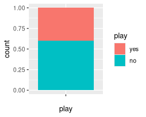

```r
ggplot(t2[2]$data) +
  geom_bar(aes(x = "", fill = play),
           position = position_fill()) +
  xlab("play")
```

So if we were to use the above code to create the desired plot for one node, we can instead pass a `'list'` of the two components to `gglist` and `geom_node_plot` will create a version of it for every specified node (per default the `terminal` nodes). Keep in mind, that since it’s a `'list'` we need to use `","` instead of `"+"` to combine the components.

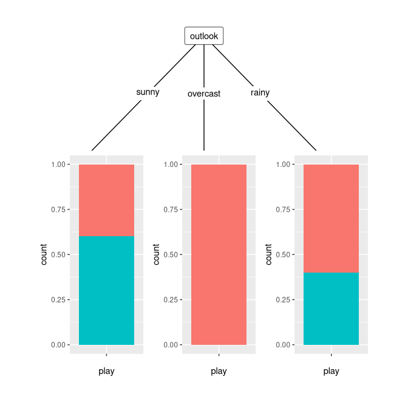

```r
ggparty(t2) +
  geom_edge() +
  geom_edge_label() +
  geom_node_splitvar() +
  # pass list to gglist containing all ggplot components we want to plot for each
  # (default: terminal) node
  geom_node_plot(gglist = list(geom_bar(aes(x = "", fill = play),
                                        position = position_fill()),
                               xlab("play")))
```

## Axes and Legends

Setting `shared_axis_labels` to `TRUE` allows us to use the space more efficiently and `legend_separator = TRUE` draws a line between the tree and the legend.

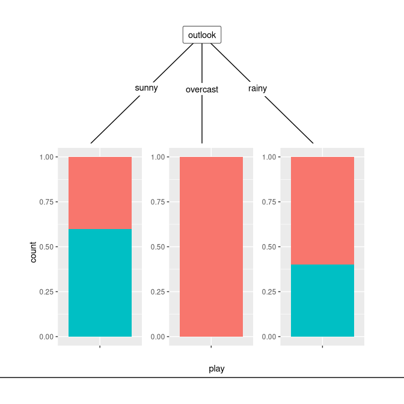

```r
ggparty(t2) +
  geom_edge() +
  geom_edge_label() +
  geom_node_splitvar() +
  geom_node_plot(gglist = list(geom_bar(aes(x = "", fill = play),
                                        position = position_fill()),
                               xlab("play")),
                 # draw only one label for each axis
                 shared_axis_labels = TRUE,
                 # draw line between tree and legend
                 legend_separator = TRUE
                 )
```

Setting `shared_legend` to `FALSE` draws an individual legend at each plot instead of one common one at the bottom of the plot. This might be necessary if we use multiple different `geom_node_plots()` which lead to various legends. In case we want to remove the legend all together (i.e. `theme(legend.position = "none")`) `shared_legend` has to be set to `FALSE`.

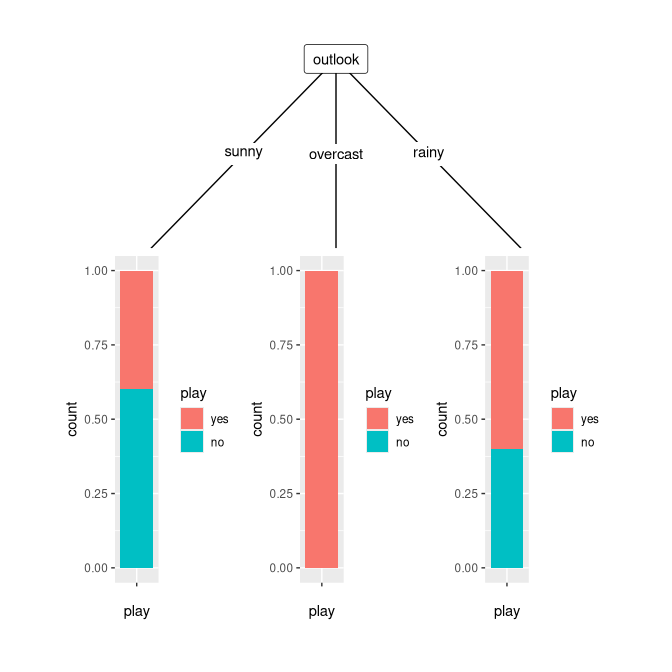

```r
ggparty(t2) +
  geom_edge() +
  geom_edge_label() +
  geom_node_splitvar() +
  geom_node_plot(gglist = list(geom_bar(aes(x = "", fill = play),
                                        position = position_fill()),
                               xlab("play")),
                 # draw individual legend for each plot
                 shared_legend = FALSE
  )
```

Thanks to the versatility of **ggplot2** we are also very flexible in creating these node plots. For example the barplot can be easily changed into a pie chart. The argument `size` of `geom_node_plot()` can be set to `"nodesize"` which changes the size of the node plot relative to the number of observations in the respective node.

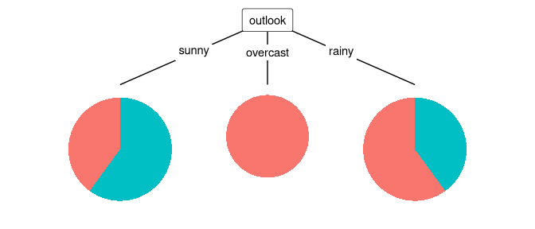

```r
ggparty(t2) +
  geom_edge() +
  geom_edge_label() +
  geom_node_splitvar() +
  # draw pie charts with their size relative to nodesize
  geom_node_plot(gglist = list(geom_bar(aes(x = "", fill = play),
                                        position = position_fill()),
                               coord_polar("y"),
                               theme_void()),
                 size = "nodesize")
```

## Predictions

If the party object contains a model with only one predictor we can use the argument `predict` to choose to show a prediction line. Additional arguments for the `geom_line()` drawing this line can be passed via `predict_gpar`.

So let’s take a look at this `'lmtree'` containing linear models explaining `eval` with `beauty`.

```r
data("TeachingRatings", package = "AER")
tr <- subset(TeachingRatings, credits == "more")

tr_tree <- lmtree(eval ~ beauty | minority + age + gender + division + native +
                    tenure, data = tr, weights = students, caseweights = FALSE)
```

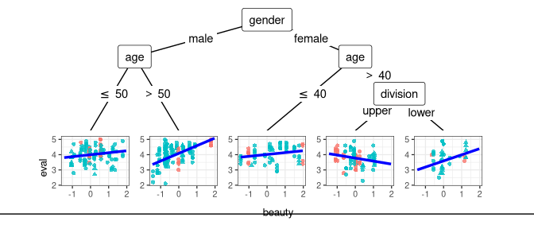

```r
ggparty(tr_tree) +
  geom_edge() +
  geom_edge_label() +
  geom_node_splitvar() +
  geom_node_plot(gglist = list(geom_point(aes(x = beauty,
                                             y = eval,
                                             col = tenure,
                                             shape = minority),
                                         alpha = 0.8),
                              theme_bw(base_size = 10)),
                shared_axis_labels = TRUE,
                legend_separator = TRUE,
                # predict based on variable
                predict = "beauty",
                # graphical parameters for geom_line of predictions
                predict_gpar = list(col = "blue",
                                   size = 1.2)
                )
```

In case we want to generate predictions for a more complicated model, we need to do this beforehand and pass the new data through the `data` argument inside `geom_node_plot()`’s `gglist`.

First the tree of class `'party'` is created using the **partykit** infrastructure.

```r
data("GBSG2", package = "TH.data")
GBSG2$time <- GBSG2$time/365

library("survival")
wbreg <- function(y, x, start = NULL, weights = NULL, offset = NULL, ...) {
  survreg(y ~ 0 + x, weights = weights, dist = "weibull", ...)
}


logLik.survreg <- function(object, ...)
  structure(object$loglik[2], df = sum(object$df), class = "logLik")

gbsg2_tree <- mob(Surv(time, cens) ~ horTh + pnodes | age + tsize +
                    tgrade + progrec + estrec + menostat, data = GBSG2,
                  fit = wbreg, control = mob_control(minsize = 80))
```

So in this case we want to create a sequence over the range of the metric variable `pnodes` and combine it once with the first level of the binary variable `horTh` and once with the second. Using this data we then (in this case) need to generate predictions of the type `"quantile"` with `p` set to `0.5`. The function `get_predictions()` can help us with the second part since it applies a `newdata` function defined by us to each node and returns a suitable `'data.frame'`.  
If we want to use it, we need to supply the `'party'` object, a function that creates the new data from each node’s `data` and optionally `predict_arg`, additional arguments to pass to the `predict()` call.

```r
# function to generate newdata for predictions
generate_newdata <- function(data) {
  z <- data.frame(horTh = factor(rep(c("yes", "no"),
                                     each = length(data$pnodes))),
                  pnodes = rep(seq(from = min(data$pnodes),
                                   to = max(data$pnodes),
                                   length.out = length(data$pnodes)),
                               2))
  z$x <- model.matrix(~ ., data = z)
  z}

# convenience function to create dataframe for predictions
pred_df <- get_predictions(gbsg2_tree,
                           # IMPORTANT to set same ids as in geom_node_plot
                           # later used for plotting
                           ids = "terminal",
                           newdata_fun = generate_newdata,
                           predict_arg = list(type = "quantile",
                                              p = 0.5)
)
```

The `'data.frame'` created this way can then be passed to any `'gg'` component in `geom_node_plot()`’s `gglist`. In this case we want to draw a line for both values of `horTh` and separate them by color.

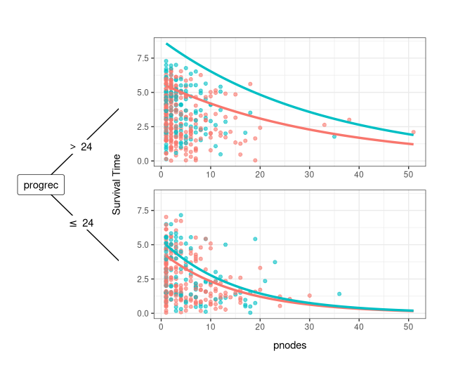

```r
ggparty(gbsg2_tree, terminal_space = 0.8, horizontal = TRUE) +
  geom_edge() +
  geom_node_splitvar() +
  geom_edge_label() +
  geom_node_plot(
    gglist = list(geom_point(aes(y = `Surv(time, cens).time`,
                                 x = pnodes,
                                 col = horTh),
                             alpha = 0.6),
                  # supply pred_df as data argument of geom_line
                  geom_line(data = pred_df,
                            aes(x = pnodes,
                                y = prediction,
                                col = horTh),
                            size = 1.2),
                  theme_bw(),
                  ylab("Survival Time")
                  ),
    ids = "terminal", # not necessary since default
    shared_axis_labels = TRUE
  )
```

## Potential Pitfalls

### Combining `'gg'` Components in `gglist` with `"+"`

The object passed to `gglist` has to be a `'list'` and therefore we must not use `"+"` to combine the components of a `geom_node_plot()` but instead `","`.

### Passing Components at the Wrong Place

As we now know, each `geom_node_plot()` is basically a completely separate plot with its own arguments and specifications which are independent from the base plot of the tree (i.e. the ggparty call with edges, labels, etc.). For that reason, if for example, we want to remove the legend of a `geom_node_plot()` we must not pass it at the base level (as a component of the tree) but inside the `gglist` of the `geom_node_plot()`.

# Node Labels

`geom_node_label()` is a modified version of **ggplot2**’s `geom_label()` which allows for multi-line labels. However the basic functionality of `geom_label()` is still present. This means that if we are content with uniform aesthetics for the whole label, we can simply use `geom_node_label()` as we would `geom_label()` with the only difference, that `x` and `y` are already mapped per default to the nodes coordinates.

If we want to have to specify even less mappings, we can use `geom_node_splitvar()` and `geom_node_info()`. These are wrappers of `geom_node_label()` with the respective defaults to plot the `splitvar` in the inner nodes or the `info` in the terminal nodes.

## Multi-Line Labels

`geom_node_label()` allows us to create multiline labels and specify individual graphical parameters for each line. To do this, we must not map anything to `label` in the `aes()` passed to `mapping`, but instead pass a `'list'` of `aes()` to the argument `line_list`. The order of the `'list'` is the same as the order in which the lines will be printed. Additionally we have to pass a `'list'` to `line_gpar`. This list must be the same `length` as `line_list` and contain separately named `'lists'` of graphical parameters. If we don’t want to change anything for a specific line, the respective ’`list'` has to be an empty `'list'`.

Mapping with the `mapping` argument of `geom_node_label()` still works and affects all lines and the border together. The line specific graphical arguments in `line_gpar` can be used to overwrite these `mappings`.  
Additionally to the usual aesthetic parameters we would use for `ggplot`’s `geom_label()` we can pass `parse` and `alignment` through `line_gpar`. Parse is equivalent to the behaviour of `geom_label()` and `alignment` enables us to position the text at the left or right label border.

All other mappings in `line_list` will be ignored. It is not possible to map other line specific aesthetics to variables. It is only possible to map the aesthetics of the complete label to variables and overwrite specific lines with fixed values in `line_gpar`. (In essence replicating the condition of mapping only one line to a variable, but we won’t be able to do this for multiple lines with different mappings).

This may seem very convoluted, but keep in mind, that we only have to go through this process if we want to address the graphical parameters of specific lines.

### Example

To create a tree consisting of inner nodes labeled by their split variable and terminal nodes labeled by their coefficients we can use the code found below.

First we need to extract the coefficients with the help of the `add_vars` argument of `ggparty()`. This step is necessary so that we can later access them by the names given to them in the `'list'` supplied to `add_vars`.

Since we want to plot different elements in the inner and terminal nodes, we need to add `geom_node_label()` twice. The first call is for the inner nodes. With the `aes()` passed to `mapping` we map the `color` of the labels to the `splitvar` of the node.

For this tree we want to display the split variable in the first line, then the p-value in scientific notation in the second line, the third line is just a spacer therefore empty and the fourth and last line is supposed to show the ID of the node. We specify the aesthetics we want to override in `line_gpar`. Using the third line as a spacer and setting `alignment` to “left” we can position the `id` of the node at the bottom left corner of the labels.  
Correspondingly we can plot the labels for the terminal nodes.

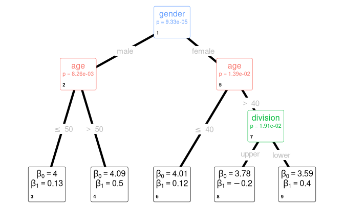

```r
ggparty(tr_tree,
        terminal_space = 0,
        add_vars = list(intercept = "$node$info$coefficients[1]",
                        beta = "$node$info$coefficients[2]")) +
  geom_edge(size = 1.5) +
  geom_edge_label(colour = "grey", size = 4) +
  # first label inner nodes
  geom_node_label(# map color of complete label to splitvar
                  mapping = aes(col = splitvar),
                  # map content to label for each line
                  line_list = list(aes(label = splitvar),
                                   aes(label = paste("p =",
                                                     formatC(p.value,
                                                             format = "e",
                                                             digits = 2))),
                                   aes(label = ""),
                                   aes(label = id)
                  ),
                  # set graphical parameters for each line in same order
                  line_gpar = list(list(size = 12),
                                   list(size = 8),
                                   list(size = 6),
                                   list(size = 7,
                                        col = "black",
                                        fontface = "bold",
                                        alignment = "left")
                  ),
                  # only inner nodes
                  ids = "inner") +
  # next label terminal nodes
  geom_node_label(# map content to label for each line
                  line_list = list(
                    aes(label = paste("beta[0] == ", round(intercept, 2))),
                    aes(label = paste("beta[1] == ",round(beta, 2))),
                    aes(label = ""),
                    aes(label = id)
                  ),
                  # set graphical parameters for each line in same order
                  line_gpar = list(list(size = 12, parse = T),
                                   list(size = 12, parse = T),
                                   list(size = 6),
                                   list(size = 7,
                                        col = "black",
                                        fontface = "bold",
                                        alignment = "left")),
                  ids = "terminal",
                  # nudge labels towards bottom so that edge labels have enough space
                  # alternatively use shift argument of edge_label
                  nudge_y = -.05) +
  # don't show legend for splitvar mapping to color since self-explanatory
  theme(legend.position = "none") +
  # html_documents seem to cut off a bit too much at the edges so set limits manually
  coord_cartesian(xlim = c(0, 1), ylim = c(-0.1, 1.1))
```

# Layout

## Nodes

```r
## Boston housing data
data("BostonHousing", package = "mlbench")
BostonHousing <- transform(BostonHousing,
                           chas = factor(chas, levels = 0:1, labels = c("no", "yes")),
                           rad = factor(rad, ordered = TRUE))

## linear model tree
bh_tree <- lmtree(medv ~ log(lstat) + I(rm^2) | zn +
                    indus + chas + nox + age + dis + rad + tax + crim + b + ptratio,
                  data = BostonHousing, minsize = 40)
```

Let’s take a look at `ggparty()`’s layout system with the help of this `'lmtree'` based on `BostonHousing` data set from **mlbench**.

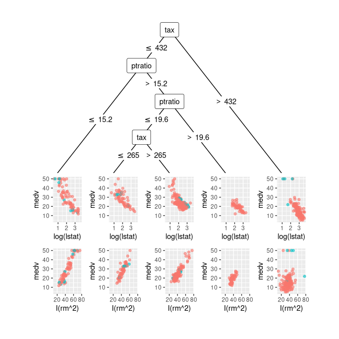

```r
# terminal space specifies at which value of y the terminal plots begin
bh_plot <- ggparty(bh_tree, terminal_space = 0.5) +
  geom_edge() +
  geom_edge_label() +
  geom_node_splitvar() +
  # plot first row
  geom_node_plot(gglist = list(
    geom_point(aes(y = medv, x = `log(lstat)`, col = chas),
               alpha = 0.6)),
    # halving the height shrinks plots towards the top
    height = 0.5) +
  # plot second row
  geom_node_plot(gglist = list(
    geom_point(aes(y = medv, x = `I(rm^2)`, col = chas),
               alpha = 0.6)),
    height = 0.5,
    # move -0.25 y to use the bottom half of the terminal space
    nudge_y = -0.25)

bh_plot
```

So if we want to plot multiple plots per node we have to keep this in mind and can achieve this for example like this.  
The first `geom_node_plot()` only takes the argument `height = 0.5` which halves its size and effectively makes it occupy only the upper half of the area it would normally do. For the second `geom_node_plot()` we also specify the size to be 0.5 but additionally we have to specify `nudge_y`. Since the terminal space is set to be 0.5, we know that the first plot now spans from 0.5 to 0.25. So we want to move the line where to place the second plot to 0.25, i.e. nudge it from 0.5 by -0.25.

Changing the theme from the default `theme_void` to one for which gridlines are drawn allows us to see the layout structure described above.

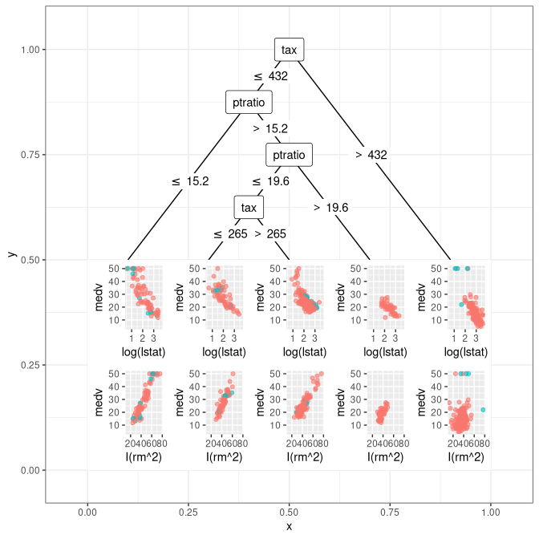

```r
bh_plot + theme_bw()
```

We can use this information to manually set the positions of nodes. To do this we must pass a `'data.frame'` containing the columns `id`, `x` and `y` to the `layout` argument of `ggparty()`.

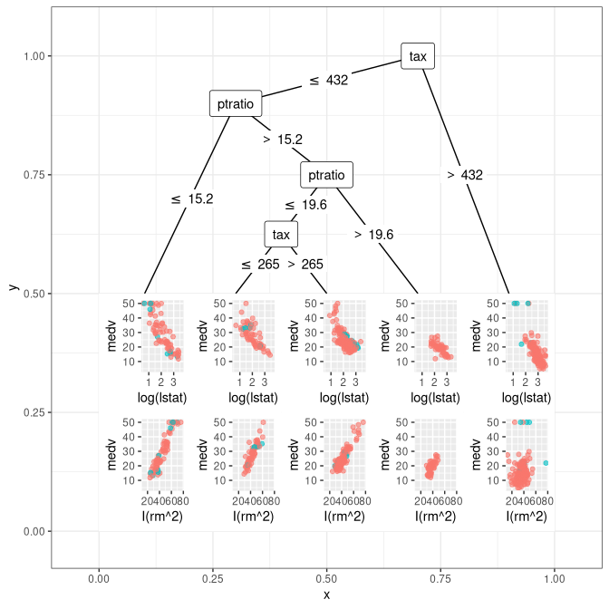

```r
ggparty(bh_tree, terminal_space = 0.5,
        # id specifies node; x and y values need to be between 0 and 1
        layout = data.frame(id = c(1, 2),
                            x = c(0.7, 0.3),
                            y = c(1, 0.9))
        ) +
  geom_edge() +
  geom_edge_label() +
  geom_node_splitvar() +
  geom_node_plot(gglist = list(
    geom_point(aes(y = medv, x = `log(lstat)`, col = chas),
               alpha = 0.6)),
    height = 0.5) +
  geom_node_plot(gglist = list(
    geom_point(aes(y = medv, x = `I(rm^2)`, col = chas),
               alpha = 0.6)),
    height = 0.5,
    nudge_y = -0.25) +
  theme_bw()
```

## Axes, Legends and Limits

As mentioned the nodes of the tree should always be positioned inside the unit square. In case of a shared legend and no shared axis labels, it is plotted at `(0.5, -0.05)` with `just = "top"`. In case shared axis labels are used, `just` changes to `"bottom"` (i.e. the legend shifts approximately `0.05 units` downwards), and the x axis label takes its position. Furthermore the shared y axis label will be plotted outside the unit square. I.e. it can often be the case that limits based on the unit square will not be sufficient to capture all elements and `ggparty()` should be able to automatically cope with these situations.  
In case you should need to adjust the x and y limits anyway, be advised to use `coord_cartesian(xlim, ylim)` instead of `ylim` and `xlim` since the latter can easily lead to unintended consequences by removing observations outside the plot limits.

# Autoplot Methods

The objects used in this document can also be plotted using the autoplot methods provided by **ggparty**.

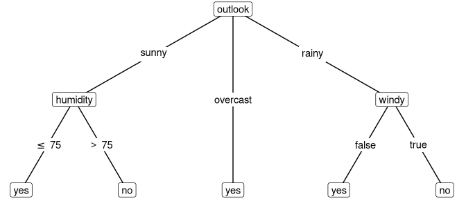

```r
autoplot(py)
```

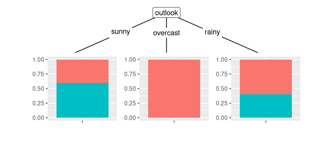

```r
autoplot(t2)
```

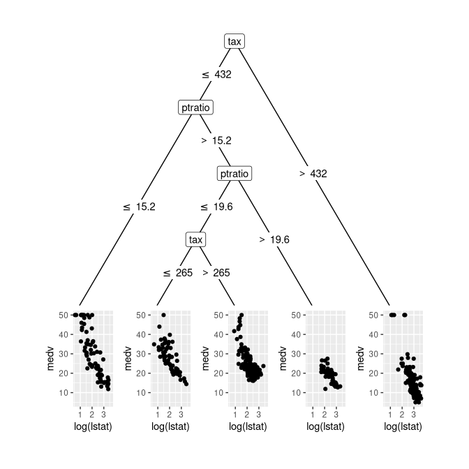

```r
autoplot(bh_tree, plot_var = "log(lstat)", show_fit = FALSE)
```

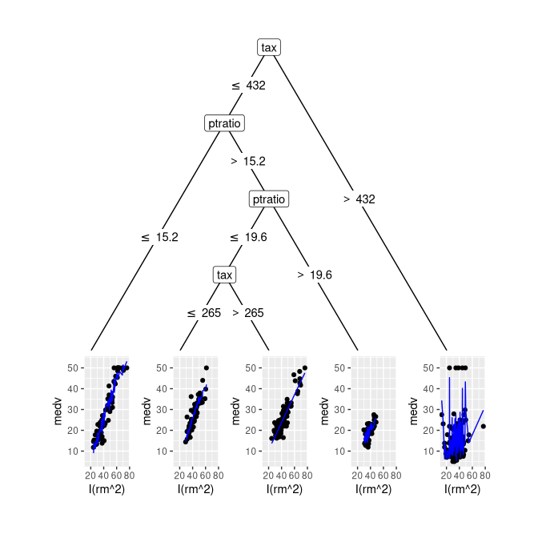

```r
autoplot(bh_tree, plot_var = "I(rm^2)", show_fit = TRUE)
```

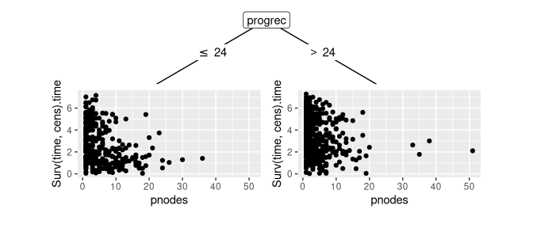

```r
autoplot(gbsg2_tree, plot_var = "pnodes")
```

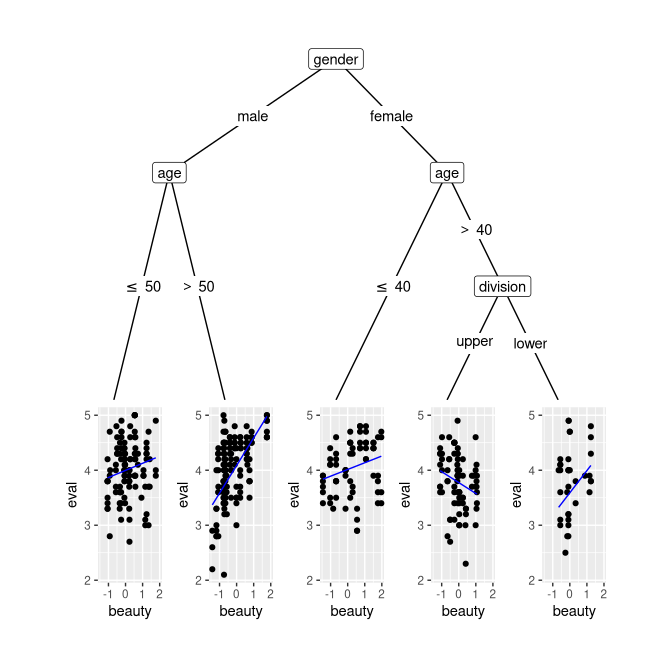

```r
autoplot(tr_tree)
```

# Examples

Using the techniques covered in this document we should now be able to plot quite nice trees of any `'party'` object without much effort. Let’s take a look at a few possibilities using the `tr_tree` we are already familiar with.

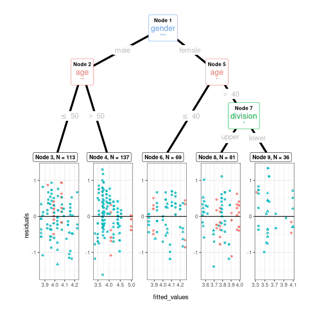

```r
asterisk_sign <- function(p_value) {
  if (p_value < 0.001) return(c("***"))
  if (p_value < 0.01) return(c("**"))
  if (p_value < 0.05) return(c("*"))
  else return("")
}


ggparty(tr_tree,
        terminal_space = 0.5) +
  geom_edge(size = 1.5) +
  geom_edge_label(colour = "grey", size = 4) +
  # plot fitted values against residuals for each terminal model
  geom_node_plot(gglist = list(geom_point(aes(x = fitted_values,
                                             y = residuals,
                                             col = tenure,
                                             shape = minority),
                                         alpha = 0.8),
                               geom_hline(yintercept = 0),
                               theme_bw(base_size = 10)),
                 # y scale is fixed for better comparability,
                 # x scale is free for effecient use of space
                 scales = "free_x",
                 ids = "terminal",
                 shared_axis_labels = TRUE
  ) +
  # label inner nodes
  geom_node_label(aes(col = splitvar),
                  # label nodes with ID, split variable and p value
                  line_list = list(aes(label = paste("Node", id)),
                                   aes(label = splitvar),
                                   aes(label = asterisk_sign(p.value))
                                   ),
                  # set graphical parameters for each line
                  line_gpar = list(list(size = 8, col = "black", fontface = "bold"),
                                   list(size = 12),
                                   list(size = 8)
                                   ),
                  ids = "inner") +
  # add labels for terminal nodes
  geom_node_label(aes(label = paste0("Node ", id, ", N = ", nodesize)),
                  fontface = "bold",
                  ids = "terminal",
                  size = 3,
                  # 0.01 nudge_y is enough to be above the node plot since a terminal
                  # nodeplot's top (not center) is at the node's coordinates.
                  nudge_y = 0.01) +
  theme(legend.position = "none")
```

This is the code for the example at the beginning of the document.

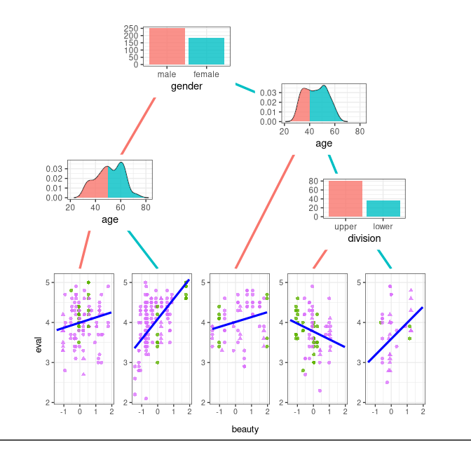

```r
# create dataframe with ids, densities and breaks
# since we are going to supply the data.frame directly to a geom inside gglist,
# we don't need to worry about the number of observations per id and only data for the ids
# used by the respective geom_node_plot() needs to be generated (2 and 5 in this case)
dens_df <- data.frame(x_dens = numeric(), y_dens = numeric(), id = numeric(), breaks = character())
for (id in c(2, 5)) {
  x_dens <- density(tr_tree[id]$data$age)$x
  y_dens <- density(tr_tree[id]$data$age)$y
  breaks <- rep("left", length(x_dens))
  if (id == 2) breaks[x_dens > 50] <- "right"
  if (id == 5) breaks[x_dens > 40] <- "right"
  dens_df <- rbind(dens_df, data.frame(x_dens, y_dens, id, breaks))
  }

# adjust layout so that each node plot has enough space
ggparty(tr_tree, terminal_space = 0.4,
        layout = data.frame(id = c(1, 2, 5, 7),
                            x = c(0.35, 0.15, 0.7, 0.8),
                            y = c(0.95, 0.6, 0.8, 0.55))) +
  # map color of edges to birth_order (order from left to right)
  geom_edge(aes(col = factor(birth_order)),
            size = 1.2,
            alpha = 1,
            # exclude root so it doesn't count as it's own colour
            ids = -1) +
  # density plots for age splits
  geom_node_plot(ids = c(2, 5),
                 gglist = list( # supply dens_df and plot line
                   geom_line(data = dens_df,
                             aes(x = x_dens,
                                 y = y_dens),
                             show.legend = FALSE,
                             alpha = 0.8),
                   # supply dens_df and plot ribbon, map color to breaks
                   geom_ribbon(data = dens_df,
                               aes(x = x_dens,
                                   ymin = 0,
                                   ymax = y_dens,
                                   fill = breaks),
                               show.legend = FALSE,
                               alpha = 0.8),
                   xlab("age"),
                   theme_bw(),
                   theme(axis.title.y = element_blank())),
                 size = 1.5,
                 height = 0.5
  ) +
  # plot bar plot of gender at root
  geom_node_plot(ids = 1,
                 gglist = list(geom_bar(aes(x = gender, fill = gender),
                                                   show.legend = FALSE,
                                                   alpha = .8),
                               theme_bw(),
                               theme(axis.title.y = element_blank())),
                 size = 1.5,
                 height = 0.5
  ) +
  # plot bar plot of division for node 7
  geom_node_plot(ids = 7,
                 gglist = list(geom_bar(aes(x = division, fill = division),
                                        show.legend = FALSE,
                                        alpha = .8),
                               theme_bw(),
                               theme(axis.title.y = element_blank())),
                 size = 1.5,
                 height = 0.5
  ) +
  # plot terminal nodes with predictions
  geom_node_plot(gglist = list(geom_point(aes(x = beauty,
                                              y = eval,
                                              col = tenure,
                                              shape = minority),
                                          alpha = 0.8),
                               theme_bw(base_size = 10),
                               scale_color_discrete(h.start = 100)),
                 shared_axis_labels = TRUE,
                 legend_separator = TRUE,
                 predict = "beauty",
                 predict_gpar = list(col = "blue",
                                    size = 1.1)) +
  # remove all legends from top level since self explanatory
  theme(legend.position = "none")
```